# Analyzing UMI-4C data with UMI4Cats

Mireia Ramos-Rodríguez and Marc Subirana-Granés

28 abril 2021

#### Package

UMI4Cats 1.1.9

# Contents

[figure not shown]

# 1 Introduction

Hello stranger! If you are here, that means you’ve successfully completed the UMI-4C protocol and got some sequencing results! The objective of this vignette is to guide you through a simple analysis of your brand-new UMI-4C contact data. Let’s dive in!

```r
library(UMI4Cats)
```

## 1.1 Overview of the package

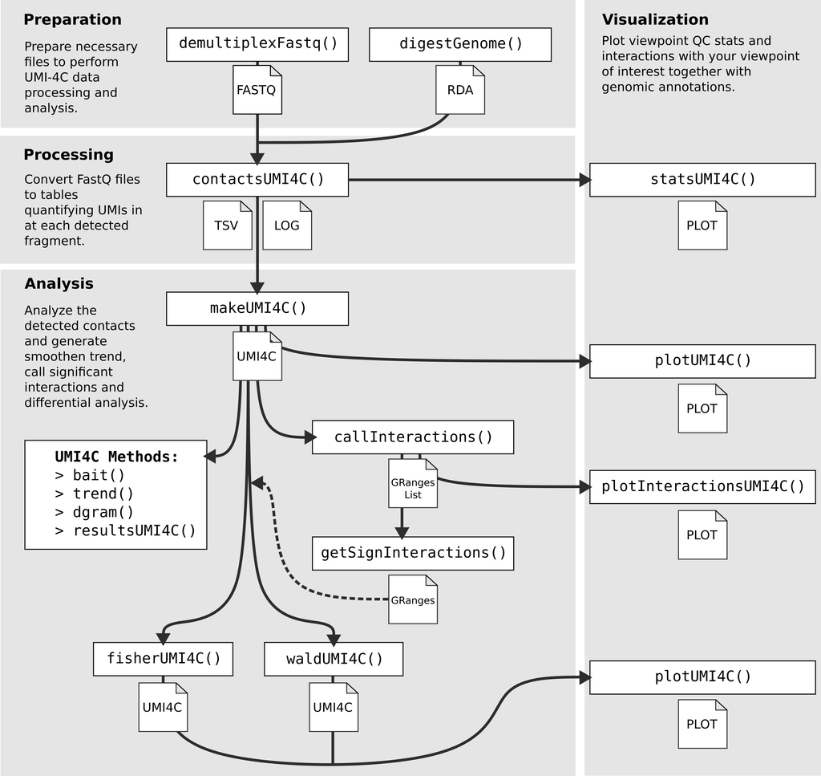

Figure 1: Overview of the different functions included in the UMI4Cats package to analyze UMI-4C data

## 1.2 About the experimental design

One of the strengths of the UMI-4C assay (Schwartzman et al. 2016) is that of reducing the PCR duplication bias, allowing a more accurate quantification of chromatin interactions. For this reason, UMI-4C is mostly used when trying to compare changes in chromatin interactions between two conditions, cell types or developmental stages.

Taking into account this main application, UMI4Cats has been developed to facilitate the differential analysis between conditions at a given viewpoint of interest. When analyzing your data with this package, you should take into account the following points:

- Each analysis (and `UMI4C` object) should correspond to the **same viewpoint**. If you are analyzing different viewpoints in the same or different loci, you need to analyze them separately.
- The UMI4Cats package is mostly oriented to the performance of differential analysis. If you don’t have replicates yet or want to focus your analysis on a specific set of regions (like enhancers) we recommend you to use Fisher’s Exact Test (`fisherUMI4C()`). If, on the other hand, you have several replicates, you might benefit from using a DESeq2 differential test specific for UMI-4C data (`differentialNbinomWaldTestUMI4C()`) or you can continue to use Fisher’s exact test.
- When performing the differential analysis, UMI4Cats is only able to deal with a **condition with 2 different levels**. If you have more than two conditions, you should produce different UMI4C objects and perform pairwise comparisons.

## 1.3 About the example datasets

The datasets used in this vignette (obtained from Ramos-Rodríguez et al. (2019)) are available for download if you want to reproduce the contents of this vignette through the `downloadUMI4CexampleData()`.

Briefly, the datasets correspond to human pancreatic islets exposed (`cyt`) or not (`ctrl`) to pro-inflammatory cytokines for 48 hours. In this example we are using the UMI-4C data generated from two different biological replicates (HI24 and HI32) using the promoter of the *CIITA* gene as viewpoint.

Sample datasets can be downloaded using the `downloadUMI4CexampleData()` function. When used without arguments, will download the full sample fastq files containing 200K reads. However, in order to reduce computing time, the *Processing UMI-4C FASTQ files* section in this vignette uses a reduced sample file containing 100 reads, which can be downloaded using `downloadUMI4CexampleData(reduced = TRUE)`. The following sections addressing analysis and visualization of such data use the processed files from the 200K fastq files, which are also included inside the package and can be accessed using the `system.file()` function.

# 2 Quick start

In this section we summarize a complete analysis using the examples provided in this package:

```r
## 0) Download example data -------------------------------
path <- downloadUMI4CexampleData()

## 1) Generate Digested genome ----------------------------
# The selected RE in this case is DpnII (|GATC), so the cut_pos is 0, and the res_enz "GATC".
hg19_dpnii <- digestGenome(
    cut_pos = 0,
    res_enz = "GATC",
    name_RE = "DpnII",
    ref_gen = BSgenome.Hsapiens.UCSC.hg19::BSgenome.Hsapiens.UCSC.hg19,
    out_path = file.path(tempdir(), "digested_genome/")
)

## 2) Process UMI-4C fastq files --------------------------
raw_dir <- file.path(path, "CIITA", "fastq")

contactsUMI4C(
    fastq_dir = raw_dir,
    wk_dir = file.path(path, "CIITA"),
    bait_seq = "GGACAAGCTCCCTGCAACTCA",
    bait_pad = "GGACTTGCA",
    res_enz = "GATC",
    cut_pos = 0,
    digested_genome = hg19_dpnii,
    bowtie_index = file.path(path, "ref_genome", "ucsc.hg19.chr16"),
    ref_gen = BSgenome.Hsapiens.UCSC.hg19::BSgenome.Hsapiens.UCSC.hg19,
    threads = 5
)

## 3) Get filtering and alignment stats -------------------
statsUMI4C(wk_dir = file.path(path, "CIITA"))

## 4) Analyze the results ---------------------------------
# Load sample processed file paths
files <- list.files(file.path(path, "CIITA", "count"),
                    pattern = "*_counts.tsv.gz",
                    full.names = TRUE
)

# Create colData including all relevant information
colData <- data.frame(
    sampleID = gsub("_counts.tsv.gz", "", basename(files)),
    file = files,
    stringsAsFactors = FALSE
)

library(tidyr)
colData <- colData %>%
    separate(sampleID,
        into = c("condition", "replicate", "viewpoint"),
        remove = FALSE
    )

# Make UMI-4C object including grouping by condition
umi <- makeUMI4C(
    colData = colData,
    viewpoint_name = "CIITA",
    grouping = "condition",
    bait_expansion = 2e6
)

# Plot replicates
plotUMI4C(umi, grouping=NULL)

## 5) Differential testing ----------------------
# Fisher test
umi_fisher <- fisherUMI4C(umi, filter_low = 30, grouping="condition")
plotUMI4C(umi_fisher, ylim = c(0, 10), grouping="condition")

# DESeq2 Wald Test
umi_wald <- differentialNbinomWaldTestUMI4C(umi4c=umi,
                                            design=~condition,
                                            alpha = 20)
plotUMI4C(umi_wald, ylim = c(0, 10), grouping="condition")
```

# 3 Preparing necessary files

## 3.1 Demultiplexing FastQ files containing multiple baits

One of the many advantages of using the UMI-4C protocol is that it allows multiplexing of different baits using the same sample.

To facilitate the analysis, UMI4Cats provides a function for demultiplexing the paired-end FastQ files returned by the sequencing facility: `demultiplexFastq`.

This function requires the following inputs:

- Name of the R1 file as input – it will automatically detect the R2.
- Barcode sequences.
- Path and name for the output files.

The barcode sequences and names to be used for each output file need to be provided as a `data.frame` with column names `sample` and `barcode`.

```r
## Input files
path <- downloadUMI4CexampleData(reduced=TRUE)
fastq <- file.path(path, "CIITA", "fastq", "ctrl_hi24_CIITA_R1.fastq.gz")

## Barcode info
barcodes <- data.frame(
    sample = c("CIITA"),
    barcode = c("GGACAAGCTCCCTGCAACTCA")
)

## Output path
out_path <- tempdir()

## Demultiplex baits inside FastQ file
demultiplexFastq(
    fastq = fastq,
    barcodes = barcodes,
    out_path = out_path
)
```

## 3.2 Reference genome digestion

For the processing of the UMI-4C FastQ files it is necessary to construct a digested genome using the same restriction enzyme that was used in the UMI-4C experiments.

The `UMI4Cats` package includes the `digestGenome()` function to make this process easier. The function uses a `BSgenome` object as the reference genome, which is digested *in silico* at a given restriction enzyme cutting sequence (`res_enz`). Besides the restriction sequence, it is also necessary to provide, as a zero-based numeric integer, the position at which the restriction enzyme cuts (`cut_pos`).

More information on `BSgenome` package and objects can be found [here](https://bioconductor.org/packages/release/bioc/html/BSgenome.html)

In the following table you can see three examples of the different cutting sequences for *DpnII*, *Csp6I* and *HindIII*.

| Restriction enzyme | Restriction seq | `res_enz` | `cut_pos` |
| --- | --- | --- | --- |
| DpnII | :`GATC` | GATC | 0 |
| Csp6I | `G`:`TAC` | GTAC | 1 |
| HindIII | `A`:`AGCTT` | AAGCTT | 1 |

For this example, we are using the hg19 `BSGenome` object and we are going to digest it using the *DpnII* enzyme.

```r
library(BSgenome.Hsapiens.UCSC.hg19)
refgen <- BSgenome.Hsapiens.UCSC.hg19

hg19_dpnii <- digestGenome(
    res_enz = "GATC",
    cut_pos = 0,
    name_RE = "dpnII",
    ref_gen = refgen,
    sel_chr = "chr16", # Select bait's chr (chr16) to make example faster
    out_path = file.path(tempdir(), "digested_genome/")
)

hg19_dpnii
```

```
#> [1] "/tmp/Rtmp5fWgR1/digested_genome//BSgenome.Hsapiens.UCSC.hg19_dpnII"
```

The digested genome will be saved in the `out_path` directory as RData objects, one for each chromosome. The path of the digested genome files is outputed by the function, so you can save it as a variable (in this case `hg19_dpnii`) and use it for downstream analyses.

# 4 Processing UMI-4C FASTQ files

Before doing any analysis, we need to convert paired-end reads stored in the FastQ files to UMI counts in the fragments returned from the *in silico* digestion of the genome, which represent contact frequencies of the viewpoint with that specific fragment. This processing is implemented in the function `contactsUMI4C()`, which should be ran in samples generated with the same experimental design (same viewpoint and restriction enzyme).

The function will consider all FastQ files in the same folder `fastq_dir` to be part of the same experiment (viewpoint + restriction enzyme). However, if you want to specify a subset of samples to perform the analysis you can do so by using the `file_pattern` argument. This way, only the files matching the specified pattern will be used as input.

The R1 and R2 files for the each sample need to contain `_R1` or `_R2` and one of the following FastQ suffixes: `.fastq`, `.fq`, `.fq.gz` or `.fastq.gz`.

For each experiment, the user needs to define 3 different sequences:

- **Bait/viewpoint sequence** (`bait_seq`). This is the downstream primer sequence (DS primer) that matches the sequence of the queried viewpoint.
- **Padding sequence** (`bait_pad`). The padding sequence corresponds to the nucleotides between the DS primer end and the next restriction enzyme site.
- **Restriction enzyme sequence** (`res_enz`). This sequence is the sequence recognized by the restriction enzyme used in the experiment.

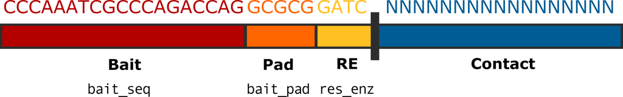

Figure 2: Schematic of a UMI-4C read detailing the different elements that need to be used as input for processing the data

Additionally, it is necessary to define the restriction enzyme cutting position (`cut_pos`) as previously done for the digested genome generation, together with the path of such digested genome (`digested_genome`) returned by the `digestGenome()` function.

`contactsUMI4C()` performs the alignment using [Bowtie2](http://bowtie-bio.sourceforge.net/bowtie2/index.shtml) and thus, you need to provide the reference genome indexes generated with bowtie2. Remember to make sure that both your Bowtie2 index and your reference and digested genomes correspond to the same build (in this example, hg19).

See the [getting started section](http://bowtie-bio.sourceforge.net/bowtie2/manual.shtml#getting-started-with-bowtie-2-lambda-phage-example) on the Bowtie2 page for more information on how to generate the index for the reference genome.

```r
## Use reduced example to make vignette faster
## If you want to download the full dataset, set reduced = FALSE or remove
## the reduce argument.
## The reduced example is already downloaded in the demultiplexFastq chunk.

# path <- downloadUMI4CexampleData(reduced=TRUE)
raw_dir <- file.path(path, "CIITA", "fastq")
index_path <- file.path(path, "ref_genome", "ucsc.hg19.chr16")

## Run main function to process UMI-4C contacts
contactsUMI4C(
    fastq_dir = raw_dir,
    wk_dir = file.path(path, "CIITA"),
    file_pattern = "ctrl_hi24_CIITA", # Select only one sample to reduce running time
    bait_seq = "GGACAAGCTCCCTGCAACTCA",
    bait_pad = "GGACTTGCA",
    res_enz = "GATC",
    cut_pos = 0,
    digested_genome = hg19_dpnii,
    bowtie_index = index_path,
    ref_gen = BSgenome.Hsapiens.UCSC.hg19::BSgenome.Hsapiens.UCSC.hg19,
    sel_seqname = "chr16", # Input bait chr to reduce running time
    threads = 2
)
```

```
#>
#> [2021-04-28 11:05:56] Starting prepUMI4C using:
#>  > Fastq directory:
#>  /tmp/Rtmp5fWgR1/UMI4Cats_data_reduced/CIITA/fastq
#>  > Work directory: /tmp/Rtmp5fWgR1/UMI4Cats_data_reduced/CIITA
#>  > Bait sequence: GGACAAGCTCCCTGCAACTCA
#>  > Bait pad: GGACTTGCA
#>  > Restriction enzyme: GATC
#>  > Number of reads loaded into memory: 1e+09
#> [2021-04-28 11:05:57] Finished sample ctrl_hi24_CIITA
#>
#> [2021-04-28 11:05:57] Starting splitUMI4C using:
#>  > Work directory: /tmp/Rtmp5fWgR1/UMI4Cats_data_reduced/CIITA
#>  > Cut position: 0
#>  > Restriction enzyme: GATC
#>  > Number of reads loaded into memory: 1e+09
#> [2021-04-28 11:05:57] Finished sample ctrl_hi24_CIITA_R1.fq.gz
#> [2021-04-28 11:05:57] Finished sample ctrl_hi32_CIITA_R1.fq.gz
#> [2021-04-28 11:05:57] Finished sample cyt_hi24_CIITA_R1.fq.gz
#> [2021-04-28 11:05:58] Finished sample cyt_hi32_CIITA_R1.fq.gz
#> [2021-04-28 11:05:58] Finished sample ctrl_hi24_CIITA_R2.fq.gz
#> [2021-04-28 11:05:58] Finished sample ctrl_hi32_CIITA_R2.fq.gz
#> [2021-04-28 11:05:58] Finished sample cyt_hi24_CIITA_R2.fq.gz
#> [2021-04-28 11:05:58] Finished sample cyt_hi32_CIITA_R2.fq.gz
#>
#> [2021-04-28 11:05:58] Starting alignmentUMI4C using:
#>  > Work directory: /tmp/Rtmp5fWgR1/UMI4Cats_data_reduced/CIITA
#>  > Viewpoint position: chr16:10972515-10972548
#>  > Reference genome: /tmp/Rtmp5fWgR1/UMI4Cats_data_reduced/ref_genome/ucsc.hg19.chr16
#>  > Number of threads: 2
#> [2021-04-28 11:05:59] Finished sample ctrl_hi24_CIITA_R1.fq
#> [2021-04-28 11:05:59] Finished sample ctrl_hi24_CIITA_R2.fq
#> [2021-04-28 11:05:59] Finished sample ctrl_hi32_CIITA_R1.fq
#> [2021-04-28 11:06:00] Finished sample ctrl_hi32_CIITA_R2.fq
#> [2021-04-28 11:06:00] Finished sample cyt_hi24_CIITA_R1.fq
#> [2021-04-28 11:06:00] Finished sample cyt_hi24_CIITA_R2.fq
#> [2021-04-28 11:06:00] Finished sample cyt_hi32_CIITA_R1.fq
#> [2021-04-28 11:06:00] Finished sample cyt_hi32_CIITA_R2.fq
#>
#> [2021-04-28 11:06:00] Starting counterUMI4C using:
#>  > Work directory: /tmp/Rtmp5fWgR1/UMI4Cats_data_reduced/CIITA
#>  > Viewpoint position: chr16:10972515-10972548
#>  > Restriction enzyme: GATC
#>  > Digested genome: /tmp/Rtmp5fWgR1/digested_genome//BSgenome.Hsapiens.UCSC.hg19_dpnII
#> [2021-04-28 11:06:02] Finished sample ctrl_hi24_CIITA
#> [2021-04-28 11:06:02] Finished sample ctrl_hi32_CIITA
#> [2021-04-28 11:06:03] Finished sample cyt_hi24_CIITA
#> [2021-04-28 11:06:04] Finished sample cyt_hi32_CIITA
```

Internally, `contactsUMI4C()` runs the following processes sequentially:

1. **FastQ files preparation (`prepUMI4C`)**. In this processing step, only reads containing the `bait_seq` + `bait_pad` + `res_enz` are selected. Reads with mean Phread quality scores < 20 are filtered out.
2. **Split reads at restriction sites (`splitUMI4C`)**. Using the `res_enz` sequence and the cutting position (`cut_pos`), all R1 and R2 reads are split to mimic the fragments generated experimentally.
3. **Align split reads to the reference genome (`alignmentUMI4C`)**.
4. **Collapse reads using UMIs (`counterUMI4C`)**. This step is done to count real molecular events and reduce artifacts due to PCR duplicates. The function returns contacts with restriction fragments < 5Mb from the viewpoint.

**Note on memory usage**: For the preparation and splitting, the FastQ files are loaded into memory. If you are having problems with the memory size available in your computer, you can change the number of lines that are to be loaded using the `numb_reads` parameter. See `?contactsUMI4C` for more information.

The final output of this process is a compressed `tsv` file stored in `wk_dir/count`, which contains the coordinates for each contact (viewpoint + contact) and the number of UMIs that support that specific interaction. These files will be used as input for the analyses performed in the following section.

## 4.1 Quality control measures

Once the processing step has been ran, the statistics of the UMI-4C filtering, alignment and final number of UMIs can be generated from the logs returned by the `contactsUMI4C()` function. By using these logs, the function `statsUMI4C()` will produce a summary plot and a summary table with all statistics (`wk_dir/logs/stats_summary.txt`).

For demonstration purposes we used a reduced version of the fastq files to reduce comptutation time. Thus, now we will load the output of `contactsUMI4C()` with the full dataset, which has ben pre-computed and is saved within the UMI4Cats package.

```r
# Using the full dataset included in the package
statsUMI4C(wk_dir = system.file("extdata", "CIITA",
    package = "UMI4Cats"
))
```

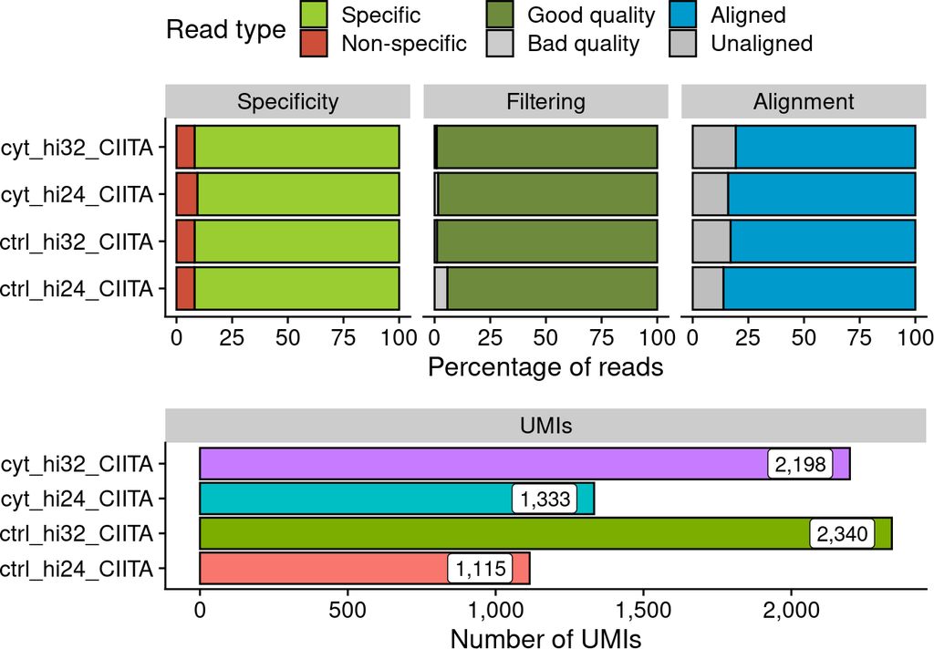

```r
# Read stats table
stats <- read.delim(system.file("extdata", "CIITA", "logs", "stats_summary.txt",
    package = "UMI4Cats"
))

knitr::kable(stats)
```

| sample_id | specific_reads | nonspecific_reads | filtered_reads | filtout_reads | al_mapped | al_unmapped | umi |
| --- | --- | --- | --- | --- | --- | --- | --- |
| ctrl_hi24_CIITA | 183831 | 16169 | 173342 | 10489 | 473730 | 75809 | 1115 |
| ctrl_hi32_CIITA | 183759 | 16241 | 181789 | 1970 | 479286 | 98065 | 2340 |
| cyt_hi24_CIITA | 181278 | 18722 | 178473 | 2805 | 479134 | 90485 | 1333 |
| cyt_hi32_CIITA | 183770 | 16230 | 182106 | 1664 | 466677 | 111822 | 2198 |

The quality control measures summarized in the plot and the table are:

- **Specific reads**. Corresponds to the number of reads that contain the full viewpoint sequence (`bait_seq` + `bait_pad` + `res_enz`).
- **Filtered reads**. Number of reads with mean Phred quality scores `>= 20`.
- **Mapping stats**. Indicates how many split reads are mapped or unmapped to the reference genome.
- **UMIs**. Shows the final number of molecular contacts detected.

# 5 Loading UMI-4C data into R

After processing the FastQ reads and obtaining tables summarizing number of UMIs supporting each fragment interaction with the viewpoint, the next step is to analyze such data by detecting differential contacts and visualizing the genomic interactions.

## 5.1 Build the `UMI4C` object

The first step of the UMI-4C data analysis consists on loading the tables generated by the function `contactsUMI4C()` and use them to construct a `UMI4C` object, which is based on the `SummarizedExperiment` class. All these steps are performed automatically by the `makeUMI4C()` function.

The `makeUMI4C` will need as input a data frame (`colData`) containing all relevant experiment information that will be needed for analyzing the data later on. The mandatory columns are:

1. `sampleID`: Unique identifier for the sample.
2. `replicate`: Replicate character or number identifier.
3. `condition`: Grouping variable for performing the differential analysis. For example: “control” and “treatment”, two different cell types, etc. The condition column should only have **two** different values. If more condition variables are provided, the differential analysis will fail.
4. `file`: Complete path and filename of the tsv files generated by `contactsUMI4C()`.

You can also include other additional columns to `colData`.

The `UMI4C` object will contain data from all the replicates. However, you might be interested in also including information of samples grouped using a specific variable, such as **condition**, to plot combined profiles or perform differential tests on merged replicates. The argument `grouping` controls this behavior. By default, the grouping argument is set to `grouping = "condition"`, which will group the samples according to the variables in the `condition` column. This grouped UMI4C can be accessed using `groupsUMI4C(umi4c)$condition`. You can also add additional groupings to a specific `UMI-4C` object using the `addGrouping()` function or avoid the calculation of grouped sample setting `grouping = NULL`.

Additionally, the `makeUMI4C` function also contains other arguments that can be used if you want to tweak the default parameters of the analysis. See `?makeUMI4C` to have a complete list and description of all the arguments.

```r
# Load sample processed file paths
files <- list.files(system.file("extdata", "CIITA", "count", package="UMI4Cats"),
                    pattern = "*_counts.tsv.gz",
                    full.names = TRUE
)

# Create colData including all relevant information
colData <- data.frame(
    sampleID = gsub("_counts.tsv.gz", "", basename(files)),
    file = files,
    stringsAsFactors = FALSE
)

library(tidyr)
colData <- colData %>%
    separate(sampleID,
        into = c("condition", "replicate", "viewpoint"),
        remove = FALSE
    )

# Load UMI-4C data and generate UMI4C object
umi <- makeUMI4C(
    colData = colData,
    viewpoint_name = "CIITA",
    grouping = "condition",
    ref_umi4c = c("condition"="ctrl"),
    bait_expansion = 2e6
)

umi
```

```
#> class: UMI4C
#> dim: 5853 4
#> metadata(7): bait scales ... ref_umi4c region
#> assays(6): umi norm_mat ... scale sd
#> rownames(5853): frag_1 frag_2 ... frag_5859 frag_5860
#> rowData names(2): id_contact position
#> colnames(4): ctrl_hi24_CIITA ctrl_hi32_CIITA cyt_hi24_CIITA
#>   cyt_hi32_CIITA
#> colData names(5): sampleID condition replicate viewpoint file
```

```r
groupsUMI4C(umi)
```

```
#> List of length 1
#> names(1): condition
```

The `makeUMI4C` function will perform the following steps to generate the `UMI4C` object:

1. **Remove fragment ends around the bait**, as they are generally biased because of their proximity to the viewpoint. The value of the region that will be excluded from the analysis can be specified using the `bait_exclusion` argument. The default is 3 kb.
2. **Focus the scope** of the analysis in a specific genomic region around the bait, by default this is a 2Mb window centerd on the viewpoint. The default value can be changed using the `bait_expansion` argument.
3. Sum the UMIs of the different samples belonging to the same group (defined by the `grouping` variable).
4. **Obtain the normalization matrices** that will be used to scale the groups to the reference, by default the group with less UMIs. If you want to avoid this normalization step, you can set `normalized` to `FALSE`.
5. Calculate the **domainograms** for each group.
6. Calculate the **adaptive trend** for each group.

## 5.2 Accessing `UMI4C` object information

The usual accessor functions from the `SummarizedExperiment-class` also work with the UMI-4C class (for example: `assay`, `colData`, etc.). Other additional accessors have been created to retrieve different information:

See more about the SummarizedExperiment class [here](https://bioconductor.org/packages/release/bioc/html/SummarizedExperiment.html)

- `dgram()`. Get a list of the domaingorams for each group.
- `bait()`. Retrieve a GRanges object with the bait position.
- `trend()`. Obtain a data.frame in long format with the adaptive smoothing trend.
- `resultsUMI4C()`. Retrieve results from the differential analysis. This only works if a differential analysis has been performed on the UMI4C object.

You can use this functions in the per-sample `UMI4C` object or in the grouped `UMI4C` object, which can be accessed using `groupsUMI4C(umi4c)$<groupind-variable>`. See an example below.

```r
groupsUMI4C(umi) # Available grouped UMI-4C objects
```

```
#> List of length 1
#> names(1): condition
```

```r
head(assay(umi)) # Retrieve raw UMIs
```

```
#>        ctrl_hi24_CIITA ctrl_hi32_CIITA cyt_hi24_CIITA cyt_hi32_CIITA
#> frag_1               0               0              0              0
#> frag_2               0               0              0              0
#> frag_3               0               2              0              0
#> frag_4               0               0              0              0
#> frag_5               0               0              0              0
#> frag_6               0               0              0              0
```

```r
head(assay(groupsUMI4C(umi)$condition)) # Retrieve UMIs grouped by condition
```

```
#>        ctrl cyt
#> frag_1    0   0
#> frag_2    0   0
#> frag_3    2   0
#> frag_4    0   0
#> frag_5    0   0
#> frag_6    0   0
```

```r
colData(umi) # Retrieve column information
```

```
#> DataFrame with 4 rows and 5 columns
#>                        sampleID   condition   replicate   viewpoint
#>                     <character> <character> <character> <character>
#> ctrl_hi24_CIITA ctrl_hi24_CIITA        ctrl        hi24       CIITA
#> ctrl_hi32_CIITA ctrl_hi32_CIITA        ctrl        hi32       CIITA
#> cyt_hi24_CIITA   cyt_hi24_CIITA         cyt        hi24       CIITA
#> cyt_hi32_CIITA   cyt_hi32_CIITA         cyt        hi32       CIITA
#>                                   file
#>                            <character>
#> ctrl_hi24_CIITA /home/msubirana/R/x8..
#> ctrl_hi32_CIITA /home/msubirana/R/x8..
#> cyt_hi24_CIITA  /home/msubirana/R/x8..
#> cyt_hi32_CIITA  /home/msubirana/R/x8..
```

```r
rowRanges(umi) # Retrieve fragment coordinates
```

```
#> GRanges object with 5853 ranges and 2 metadata columns:
#>             seqnames            ranges strand |  id_contact    position
#>                <Rle>         <IRanges>  <Rle> | <character> <character>
#>      frag_1    chr16   9972440-9972810      * |      frag_1    upstream
#>      frag_2    chr16   9972811-9973022      * |      frag_2    upstream
#>      frag_3    chr16   9973023-9973900      * |      frag_3    upstream
#>      frag_4    chr16   9973901-9974010      * |      frag_4    upstream
#>      frag_5    chr16   9974011-9974144      * |      frag_5    upstream
#>         ...      ...               ...    ... .         ...         ...
#>   frag_5856    chr16 11970551-11971015      * |   frag_5856  downstream
#>   frag_5857    chr16 11971016-11971304      * |   frag_5857  downstream
#>   frag_5858    chr16 11971305-11971499      * |   frag_5858  downstream
#>   frag_5859    chr16 11971500-11971588      * |   frag_5859  downstream
#>   frag_5860    chr16 11971589-11972035      * |   frag_5860  downstream
#>   -------
#>   seqinfo: 1 sequence from an unspecified genome; no seqlengths
```

```r
dgram(umi) # Retrieve domainograms
```

```
#> List of length 4
#> names(4): ctrl_hi24_CIITA ctrl_hi32_CIITA cyt_hi24_CIITA cyt_hi32_CIITA
```

```r
dgram(groupsUMI4C(umi)$condition) # Retrieve domainograms
```

```
#> List of length 2
#> names(2): ctrl cyt
```

```r
bait(umi) # Retrieve bait coordinates
```

```
#> GRanges object with 1 range and 1 metadata column:
#>       seqnames            ranges strand |        name
#>          <Rle>         <IRanges>  <Rle> | <character>
#>   [1]    chr16 10970996-10972544      * |       CIITA
#>   -------
#>   seqinfo: 1 sequence from an unspecified genome; no seqlengths
```

```r
head(trend(umi)) # Retrieve adaptive smoothing trend
```

```
#>   geo_coord      trend         sd scale id_contact          sample sampleID
#> 1  10254166 0.08333333 0.03333333   150   frag_754 ctrl_hi24_CIITA     <NA>
#> 2  10254519 0.08389262 0.03355705   149   frag_755 ctrl_hi24_CIITA     <NA>
#> 3  10254871 0.08445946 0.03378378   148   frag_756 ctrl_hi24_CIITA     <NA>
#> 4  10255223 0.08503401 0.03401361   147   frag_757 ctrl_hi24_CIITA     <NA>
#> 5  10255577 0.08561644 0.03424658   146   frag_758 ctrl_hi24_CIITA     <NA>
#> 6  10255933 0.08620690 0.03448276   145   frag_759 ctrl_hi24_CIITA     <NA>
#>   replicate viewpoint file
#> 1      <NA>      <NA> <NA>
#> 2      <NA>      <NA> <NA>
#> 3      <NA>      <NA> <NA>
#> 4      <NA>      <NA> <NA>
#> 5      <NA>      <NA> <NA>
#> 6      <NA>      <NA> <NA>
```

# 6 Calling significant interactions

This differential analysis works as follow:

1. Variance stabilizing transformation (VST) of the raw UMI counts.
2. Smooth monotone fitting of the VST counts.
3. Z-score

## 6.1 Methods

### 6.1.1 Variance stabilizing transformation (VST) of the raw counts

In 4C experiments, the standard deviations across samples are large for high abundance fragments. Such heteroscedasticity may skew the differential analysis towards fragments either far or close to the viewpoint. Variance stabilizing transformation (VST) is used to remove the dependence of the variance on the mean, thus correcting the dependence of the standard deviations to the fragment abundance.

VST is calculated performing the following steps:

1. Count data normalization using a median of ratios method.
2. Estimation of dispersions.
3. Fitting a curve to the dispersion estimates for calculating the VST.
4. Transform the count data using the VST.

### 6.1.2 Smooth monotone fitting

The 4C signal decays with genomic distance from the viewpoint and converges towards a constant level of background. 4C data reflects a smooth strictly increasing or strictly decreasing function, so it is desirable to smooth the data with a strictly monotone function. Thus, the general decay of the 4C signal with genomic distance from the viewpoint is fitted using a symmetric monotone fit.

The monotone smoothing function is calculated using the transformed raw counts, using the [`fda`](https://cran.r-project.org/package=fda) package. Then, the fitted count values are generated using such function.

### 6.1.3 Z-score

## 6.2 Obtain significant interactions

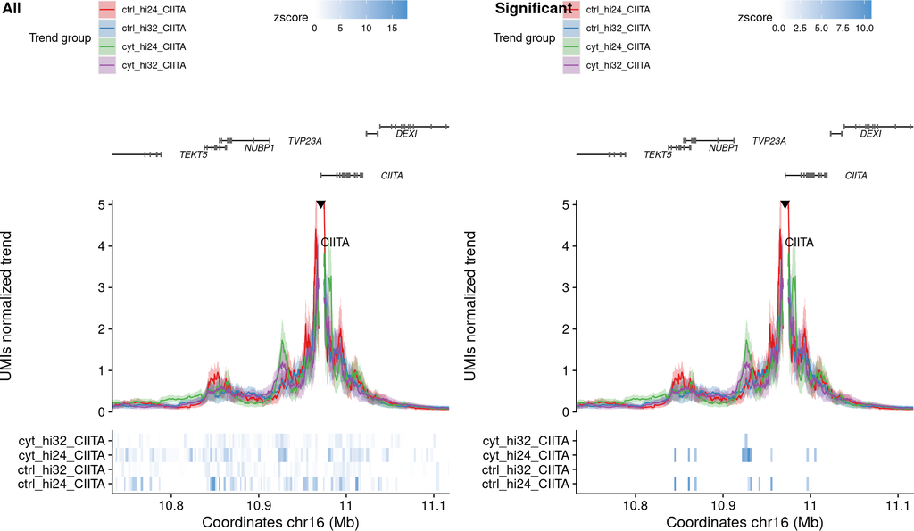

```r
# Generate windows
win_frags <- makeWindowFragments(umi, n_frags=8)

# Call interactions
gr <-  callInteractions(umi, ~condition, win_frags, padj_threshold = 0.01, zscore_threshold=2)
all <- plotInteractionsUMI4C(umi, gr, grouping = NULL, significant=FALSE, xlim=c(10.75e6, 11.1e6))
sign <- plotInteractionsUMI4C(umi, gr, grouping = NULL, significant=TRUE, xlim=c(10.75e6, 11.1e6))
cowplot::plot_grid(all, sign, ncol=2, labels=c("All", "Significant"))
```

```r
# Obtain unique significant interactions
inter <- getSignInteractions(gr)
```

[output not shown]

# 7 Differential analysis

Once the `UMI4C` object is generated, you can perform a differential analysis using two different approaches:

- **Fisher’s Exact Test** (`fisherUMI4C()`). We recommend using this test when no or few replicates are available and when the number of UMIs per replicate is not very high.
- **DESeq2’s Wald Test** (`waldUMI4C()`). In this case, 3 replicates or more are recommended, together with high UMIs per replicate.

In both cases you can provide `query_regions`, such as enhancers, open chromatin regions or the output `getSignInteractions()` to focus the anlysis in regions that are more likely to have differential interactions.

## 7.1 Differential analysis using Fisher’s Exact Test

Many times, UMI-4C is used to test whether a certain set of promoter-enhancer contacts differ between conditions or cell types. For this cases, the `fisherUMI4c()` with the argument `query_regions` set to those regions of interest can be used. Your query regions should be provided as a `GRanges` object. If your set of query regions is narrow (~1kb), you can resize them to the desired width using the `resize` argument.

First of all, queried regions will be filtered according to the median number of UMIs present in the `filter_low` parameter. You can reduce this number or disable filtering using `filter_low = FALSE`.

Then, a contingency table for each region where the differential test should be performed will be created, where the group stored in `metadata(umi)$ref_umi4c` will be used as references. The values on the contingency table correspond to the following:

| Group | Query region | Region |
| --- | --- | --- |
| Reference | $n1$ | $N1 - n1$ |
| Condition | $n2$ | $N2 - n2$ |

Where $N1$ and $N2$ correspond to the total number of UMIs in the whole analyzed region (`metadata(umi)$region`) and $n1$ and $n2$ correspond to the total number of UMIs in the query region that is to be tested.

```r
# Perform differential test
umi_dif1 <- fisherUMI4C(umi,
    grouping = "condition",
    query_regions = inter,
    filter_low = 20
)
```

## 7.2 Differential Analysis using DESeq2

It is also possible to perform a differential analysis based on `DESeq2`’s Wald test. For using this differential test it is necessary to have replicates for the grouping variable included in the design, as they are needed to calculate dispersions.

```r
umi_dif2 <- waldUMI4C(umi,
                      query_regions = inter,
                      design = ~condition)
```

Differential interactions are then tested using [`DESeq2`](https://bioconductor.org/packages/release/bioc/html/DESeq2.html)’s Negative Binomial GLM test, taking advantage of the previously calculated normalization factors and dispersion estimates.

## 7.3 Retrieve differential analysis results

Results from both Fisher’s Exact test and DESeq2 can be retrieved using the `resultsUMI4C()` on the `UMI4C` object returned by both functions.

```r
resultsUMI4C(umi_dif1, ordered = TRUE, counts = TRUE, format = "data.frame")
```

```
#>    seqnames    start      end        id mcols.position umis_ref umis_cond
#> 21    chr16 10924799 10927966 region_21       upstream       12        46
#> 9     chr16 10927967 10930640  region_9       upstream       13        41
#> 22    chr16 11003893 11006616 region_22     downstream       18        35
#> 13    chr16 10995350 10998148 region_13     downstream       40        26
#> 11    chr16 10940371 10941822 region_11       upstream       31        22
#> 10    chr16 10930641 10933175 region_10       upstream       25        34
#> 12    chr16 10954198 10956424 region_12       upstream       49        43
#> 20    chr16 10921487 10924798 region_20       upstream       30        34
#> 1     chr16 10299502 10301622  region_1       upstream        8         7
#> 2     chr16 10310432 10313385  region_2       upstream        9         2
#> 3     chr16 10353878 10356964  region_3       upstream        5         9
#> 4     chr16 10600203 10602402  region_4       upstream        2        10
#> 5     chr16 10607341 10610133  region_5       upstream       10         6
#> 6     chr16 10844428 10846299  region_6       upstream       12        26
```

[output cut: 31 more lines]

The parameter `counts` indicates whether raw counts used for the test should be outputted. In Fisher’s Exact Test, `umis_ref` corresponds to the number of raw UMIs from the sample/group used as reference (accessible through `metadata(umi_dif)$ref_umi4c`).

# 8 Visualizing UMI-4C contact data

Once the `UMI4C` object is created, you can visualize detected chromatin interactions using the `plotUMI4C` function.

The gene annotations will be extracted from the `TxDb.Hsapiens.UCSC.hg19.knownGene` package by default. Make sure that the annotations coincide with your reference genome. You can check the package [`GenomicFeatures`](https://bioconductor.org/packages/release/bioc/html/GenomicFeatures.html) for more information on available `TxDb` objects. The domainogram plotting is controlled by the `dgram_plot` argument. If you set it to `FALSE`, the domainogram will not be plotted.

In case you are interested in plotting the profiles of the different samples contained in your experiment, you just need to set the `grouping` argument to `NULL`, which will disable sample grouping:

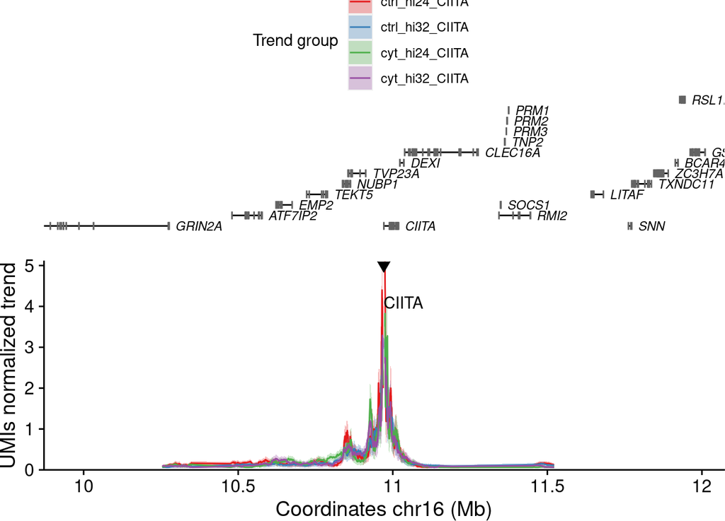

```r
plotUMI4C(umi,
    grouping = NULL,
    TxDb = TxDb.Hsapiens.UCSC.hg19.knownGene::TxDb.Hsapiens.UCSC.hg19.knownGene,
    dgram_plot = FALSE
)
```

If the `UMI4C` object contains information on the differential contacts, this data will be shown in the plot as well. The grouping argument uses the grouped trends and domainograms stored in `groupsuMI4C()`. If you want to add a new grouping, you can use the `addGRouping()` function.

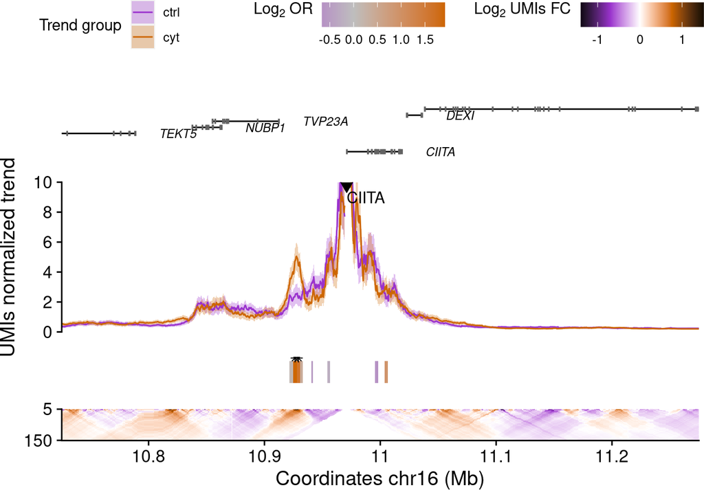

```r
plotUMI4C(umi_dif1, grouping = "condition", xlim=c(10.75e6, 11.25e6), ylim=c(0,10))
```

There are several different arguments you can provide to `plotUMI4C` to modify the output plot. You can check them by typing `?plotUMI4C` in your R console.

The `plotUMI4C` function is a wrapper for separate functions that plot the different elements included in the figure. You can use each of the functions separately if you are interesting in combining them differently or with other ggplot2 objects. Check each function documentation at `?plotTrend`, `?plotGenes`, `?plotDomainogram` and `?plotDifferential`.

# References

Ramos-Rodríguez, Mireia, Helena Raurell-Vila, Maikel L. Colli, Maria Inês Alvelos, Marc Subirana-Granés, Jonàs Juan-Mateu, Richard Norris, et al. 2019. “The impact of proinflammatory cytokines on the $\beta$-cell regulatory landscape provides insights into the genetics of type 1 diabetes.” *Nature Genetics* 51 (11): 1588–95. https://doi.org/10.1038/s41588-019-0524-6.

Schwartzman, Omer, Zohar Mukamel, Noa Oded-Elkayam, Pedro Olivares-Chauvet, Yaniv Lubling, Gilad Landan, Shai Izraeli, and Amos Tanay. 2016. “UMI-4C for quantitative and targeted chromosomal contact profiling.” *Nature Methods* 13 (8): 685–91. https://doi.org/10.1038/nmeth.3922.